# R Notebook

```r
  # setwd("C:/Users/amonion/New York State Office of Information Technology Services/BWAM - Lakes Database/Current")
  # source("new_database/Reading.LMAS.Data.R")
  # setwd("C:/Users/amonion/OneDrive - New York State Office of Information Technology Services/Rscripts/TP_Landuse")

  rm(list=setdiff(ls(), c("newdata")))
```

log transformed

Call: gam(formula = logTP ~ s(DISTURBANCE, df = 20), data = TP_matrix) Deviance Residuals: Min 1Q Median 3Q Max -0.81082 -0.20198 -0.02298 0.15926 1.36804

(Dispersion Parameter for gaussian family taken to be 0.103)

```
Null Deviance: 75.0702 on 483 degrees of freedom
```

Residual Deviance: 47.7094 on 463 degrees of freedom AIC: 296.1251

Number of Local Scoring Iterations: NA

Anova for Parametric Effects Df Sum Sq Mean Sq F value Pr(>F)  
s(DISTURBANCE, df = 20) 1 21.171 21.171 205.46 < 2.2e-16 *** Residuals 463 47.709 0.103  
— Signif. codes: 0 ‘**’ 0.001 ‘**’ 0.01 ‘’ 0.05 ‘.’ 0.1 ‘ ’ 1

Anova for Nonparametric Effects Npar Df Npar F Pr(F)  
(Intercept)  
s(DISTURBANCE, df = 20) 19 3.1615 9.549e-06 *** — Signif. codes: 0 ‘**’ 0.001 ‘**’ 0.01 ‘’ 0.05 ‘.’ 0.1 ‘ ’ 1

Call: gam(formula = logTP ~ s(DISTURBANCE, df = 20) + s(depth, df = 20), data = TP_matrix %>% filter(!is.na(depth))) Deviance Residuals: Min 1Q Median 3Q Max -0.5966309 -0.1293017 0.0004598 0.1182883 0.9747953

(Dispersion Parameter for gaussian family taken to be 0.0674)

```
Null Deviance: 32.8903 on 189 degrees of freedom
```

Residual Deviance: 10.0485 on 149.0007 degrees of freedom AIC: 64.6713

Number of Local Scoring Iterations: NA

Anova for Parametric Effects Df Sum Sq Mean Sq F value Pr(>F)  
s(DISTURBANCE, df = 20) 1 10.3488 10.3488 153.454 < 2.2e-16 *s(depth, df = 20) 1 3.3638 3.3638 49.879 5.811e-11* Residuals 149 10.0485 0.0674  
— Signif. codes: 0 ‘**’ 0.001 ‘**’ 0.01 ‘’ 0.05 ‘.’ 0.1 ‘ ’ 1

Anova for Nonparametric Effects Npar Df Npar F Pr(F)  
(Intercept)  
s(DISTURBANCE, df = 20) 19 2.2030 0.004515 ** s(depth, df = 20) 19 3.4594 9.811e-06 *** — Signif. codes: 0 ‘**’ 0.001 ‘**’ 0.01 ‘’ 0.05 ‘.’ 0.1 ‘ ’ 1

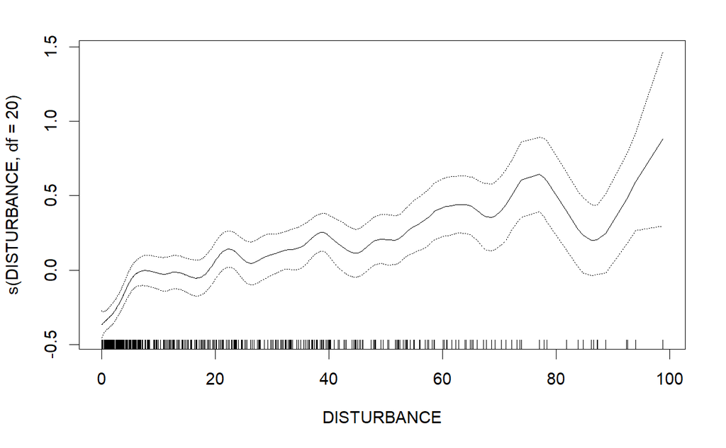

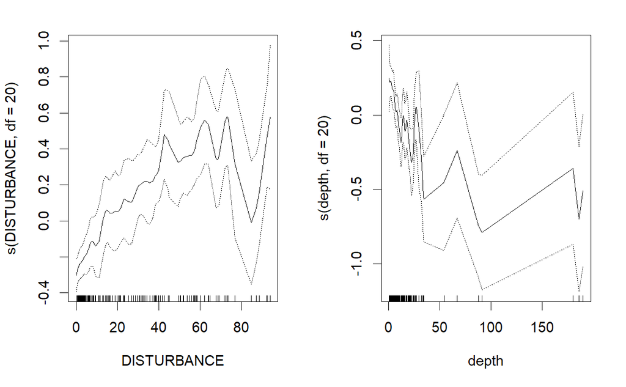